# Summary Paper: Customer Churn Analysis

Team: SNM Analytics

2023-03-30

## Chapter 1: Introduction

### Importance of Churn Modeling

The banking industry is one of the most competitive industries globally, and the sector’s competition is only increasing. To remain competitive, banks must understand their customers’ behavior and preferences to provide targeted and personalized services to retain their customer base.

One of the challenges that banks face is customer churn, which refers to the loss of customers who switch to a competitor or terminate their relationship with the bank altogether. Customer churn can result from a variety of factors, such as poor customer service, high fees, unsuitable products, or a lack of personalized services.

To mitigate the effects of customer churn, the banking industry has increasingly turned to churn modeling as a vital tool to identify the factors that influence customer retention. Churn modeling helps businesses identify key drivers of customer behavior, such as customer satisfaction, product usage, and demographic information, allowing them to develop targeted strategies to minimize churn and maintain profitability.

### Background to the project

The churn modeling dataset selected for this EDA provides a rich source of data for banks and researchers/students to develop and evaluate churn modeling algorithms. The dataset’s features, such as demographics, transnational data, and customer churn status, provide valuable insights into the factors influencing customer behavior and preferences. For instance, the dataset contains information on customers’ age, gender, location, credit score, account balance, credit card usage, and customer churn status. These features can help banks understand the underlying reasons for customer churn and develop targeted strategies to retain customers.

In this project, we will perform exploratory data analysis on a churn modeling dataset obtained from Kaggle (https://www.kaggle.com/datasets/shubh0799/churn-modelling)to help identify factors that influence customer retention, enabling them to develop strategies to minimize churn and maintain profitability. Dataset is explored to understand the characteristics of the data, clean and prepare it for further analysis, and perform some statistical tests to draw insights.

The main aim of this EDA is to answer the SMART question: ‘How does the distribution of credit score vary between customers who have churned and customers who have not churned, for customers with a balance greater than zero’.

Specific: We’ll investigate credit score distribution among two distinct groups of customers: those who have churned and those who have not churned.

Measurable: Aims to identify the extent of variation in the credit score distribution for two specific groups of customers with a balance greater than zero.

Achievable: The data can be sourced from bank’s databases.

Relevant: The question addresses a vital business concern: identifying factors contributing to customer churn and retention, crucial for financial institutions’ success.

Time-bound: Analysis can be done within a defined timeframe to meet research objectives and inform timely decision-making.

## Chapter 2: Dataset Description

### Dataset analysis

```r
# Load the dataset from csv
churn_data <- data.frame(read.csv("Data.csv"))
#Calculate the number of rows and columns in the dataset
rows <- nrow(churn_data)
cols <- ncol(churn_data)
#To check the structure of the dataset
str(churn_data)
```

```
## 'data.frame':    10000 obs. of  14 variables:
##  $ RowNumber      : int  1 2 3 4 5 6 7 8 9 10 ...
##  $ CustomerId     : int  15634602 15647311 15619304 15701354 15737888 15574012 15592531 15656148 15792365 15592389 ...
##  $ Surname        : chr  "Hargrave" "Hill" "Onio" "Boni" ...
##  $ CreditScore    : int  619 608 502 699 850 645 822 376 501 684 ...
##  $ Geography      : chr  "France" "Spain" "France" "France" ...
##  $ Gender         : chr  "Female" "Female" "Female" "Female" ...
##  $ Age            : int  42 41 42 39 43 44 50 29 44 27 ...
##  $ Tenure         : int  2 1 8 1 2 8 7 4 4 2 ...
##  $ Balance        : num  0 83808 159661 0 125511 ...
##  $ NumOfProducts  : int  1 1 3 2 1 2 2 4 2 1 ...
##  $ HasCrCard      : int  1 0 1 0 1 1 1 1 0 1 ...
##  $ IsActiveMember : int  1 1 0 0 1 0 1 0 1 1 ...
##  $ EstimatedSalary: num  101349 112543 113932 93827 79084 ...
##  $ Exited         : int  1 0 1 0 0 1 0 1 0 0 ...
```

The study is based on the dataset that contains 10,000 observations of 14 variables (Refer to the above readout of the structure of the dataset.) The dataset has 10000 observations and 14 variables.

### Variables and its descriptions

| VARIABLES | DESCRIPTION |
| --- | --- |
| Rownumber | Unique ID for every row |
| CustomerID | Unique ID for every client |
| Surname | Client’s surname |
| CreditScore | Client’s credit score |
| Geography | Country of client’s origin |
| Gender | Client’s gender |
| Age | Client’s age |
| Tenure | Number of years for which the client has been with the bank |
| Balance | Client’s balance on account |
| NumOfProducts | Number of client’s products |
| HasCrCard | Flag whether client has credit card or not |
| IsActiveMember | Flag whether client is active member of bank or not |
| EstimatedSalary | Client’s annual estimated salary in euros |
| Exited | Target variable, flag, whether client left the bank or not |

### Limitations of the dataset

One of the limitations of the churn modeling dataset is that it is unclear whether the dataset is a simulated or real-world dataset. If the dataset is simulated, then the results obtained from the analysis may not be generalized to the real world.

Limitation of the dataset is that it only contains information on bank customers, which may limit its applicability to other domains. Moreover, the dataset contains only 10,000 records, which may not be sufficient for training complex machine learning models.

The dataset does not contain information on customer feedback or satisfaction, which may limit the ability to identify the underlying reasons for customer churn.

### Related analysis on the dataset

Several studies have used the dataset to develop and evaluate various machine learning models for predicting customer churn, including logistic regression, decision tree, random forest, and support vector machine. For instance, one study used the dataset to develop a predictive model for customer churn using various machine learning algorithms, including logistic regression, decision tree, random forest, and support vector machine. The study reported that the random forest algorithm outperformed other algorithms in terms of prediction accuracy, sensitivity, and specificity.

## Chapter 3: Data Preprocessing And Cleaning

In preparation for the EDA, data cleaning was done by removing unnecessary columns, checking for missing values and filtering out zero balance customers.

### Checking for Missing Values

The dataset is checked for NULL values using the inbuilt-function ‘colSums(is.na())’

```r
na_count <- colSums(is.na(churn_data))

if (all(na_count == 0)) {
  cat("There are no missing values in the data set.\n")
} else {
  cat("There are some missing values in the data set.\n")
}
```

```
## There are no missing values in the data set.
```

Since there are no null values this data set, no additional step was taken to handle them.

### Dropping Irrelevant Variables

```r
# Remove unnecessary columns
churn_data_clean <- churn_data %>%
  select(-RowNumber, -CustomerId, -Surname)
```

### Filtering Customers with Zero Balance

```r
churn_data_clean <- churn_data %>% filter(Balance > 0)
filtered_rows <- nrow(churn_data_clean)
```

We only want to look at customers who have a positive balance as they are more valuable customers. We removed customers with a zero balance, as they are not relevant to our analysis. The filtered data set excluding zero balance has 6383 observations

### Handling Outliers

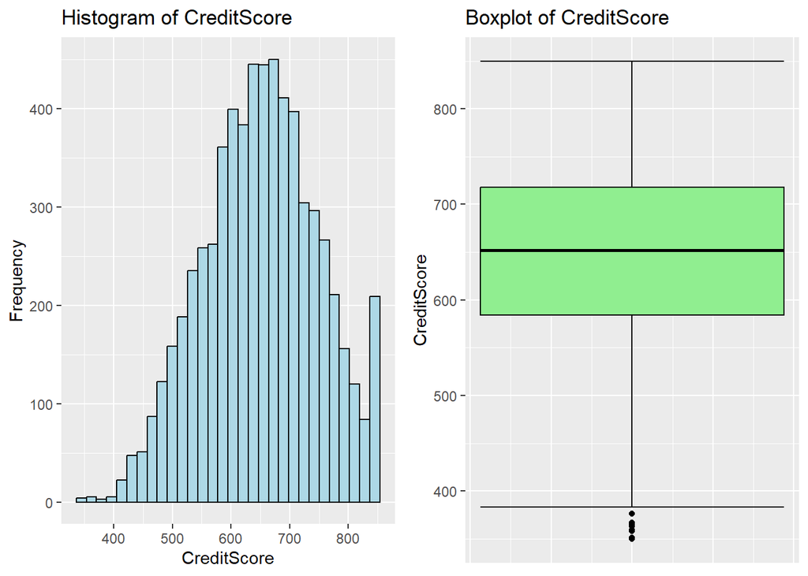

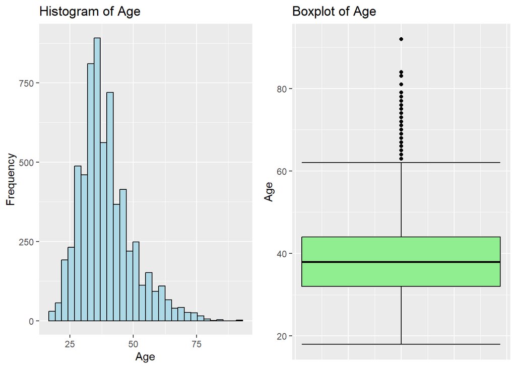

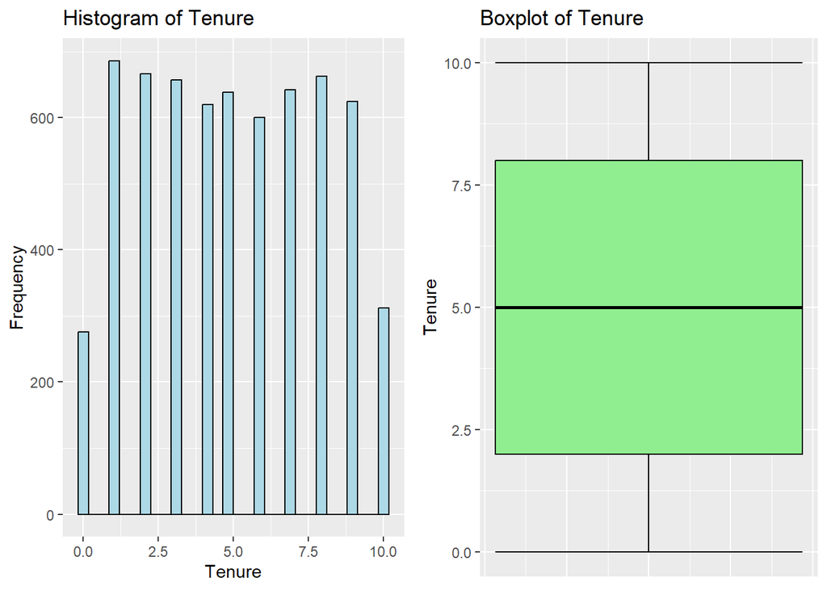

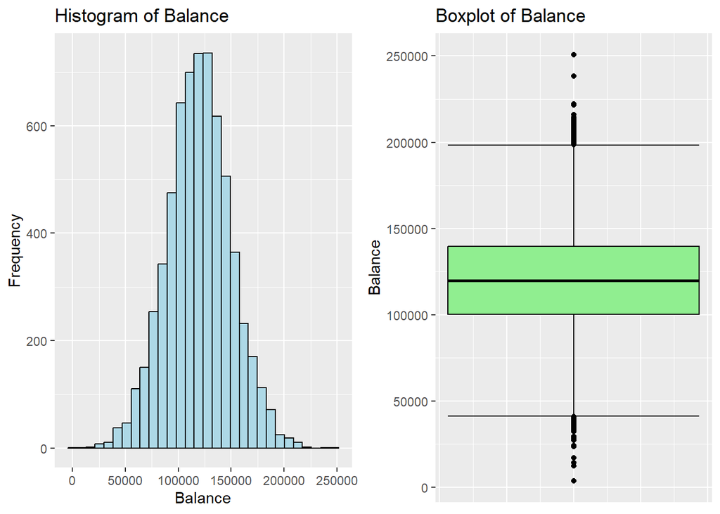

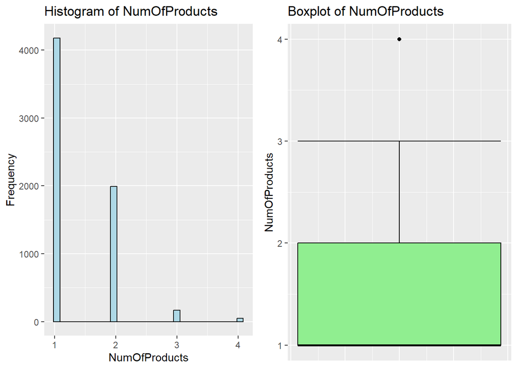

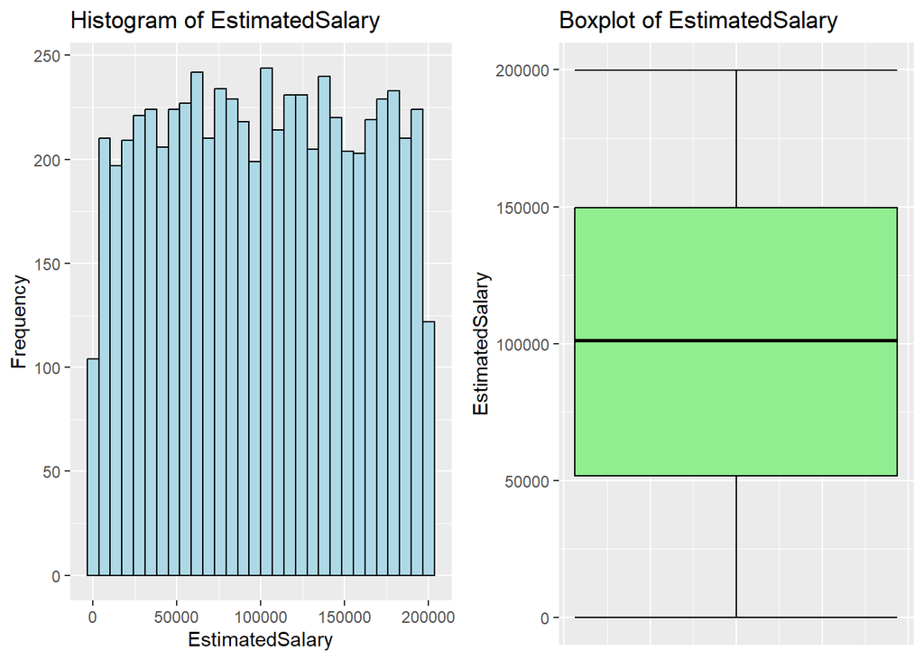

```r
# Outliers are removed to analyze the dataset more accurately
data_variables <- c("CreditScore", "Age", "Tenure", "Balance", "NumOfProducts", "EstimatedSalary")
for (var in data_variables) {
  p1 <- ggplot(churn_data_clean, aes_string(x = var)) +
    geom_histogram(bins = 30, fill = "lightblue", color = "black") +
    labs(title = paste("Histogram of", var), x = var, y = "Frequency")
  p2 <- ggplot(churn_data_clean, aes_string(x = "1", y = var)) +
    stat_boxplot(geom = "errorbar") +
    geom_boxplot(fill = "lightgreen", color = "black") +
    labs(title = paste("Boxplot of", var), x = "", y = var) +
    theme(axis.title.x = element_blank(), axis.text.x = element_blank(), axis.ticks.x = element_blank())
  gridExtra::grid.arrange(p1, p2, ncol = 2)
}
```

```r
# Getting table summary
xkablesummary(churn_data)
```

Table: Statistics summary.

|  | RowNumber | CustomerId | Surname | CreditScore | Geography | Gender | Age | Tenure | Balance | NumOfProducts | HasCrCard | IsActiveMember | EstimatedSalary | Exited |
| --- | --- | --- | --- | --- | --- | --- | --- | --- | --- | --- | --- | --- | --- | --- |
| Min | Min. : 1 | Min. :15565701 | Length:10000 | Min. :350 | Length:10000 | Length:10000 | Min. :18.0 | Min. : 0.00 | Min. : 0 | Min. :1.00 | Min. :0.000 | Min. :0.000 | Min. : 12 | Min. :0.000 |
| Q1 | 1st Qu.: 2501 | 1st Qu.:15628528 | Class :character | 1st Qu.:584 | Class :character | Class :character | 1st Qu.:32.0 | 1st Qu.: 3.00 | 1st Qu.: 0 | 1st Qu.:1.00 | 1st Qu.:0.000 | 1st Qu.:0.000 | 1st Qu.: 51002 | 1st Qu.:0.000 |
| Median | Median : 5000 | Median :15690738 | Mode :character | Median :652 | Mode :character | Mode :character | Median :37.0 | Median : 5.00 | Median : 97199 | Median :1.00 | Median :1.000 | Median :1.000 | Median :100194 | Median :0.000 |
| Mean | Mean : 5000 | Mean :15690941 | NA | Mean :651 | NA | NA | Mean :38.9 | Mean : 5.01 | Mean : 76486 | Mean :1.53 | Mean :0.706 | Mean :0.515 | Mean :100090 | Mean :0.204 |
| Q3 | 3rd Qu.: 7500 | 3rd Qu.:15753234 | NA | 3rd Qu.:718 | NA | NA | 3rd Qu.:44.0 | 3rd Qu.: 7.00 | 3rd Qu.:127644 | 3rd Qu.:2.00 | 3rd Qu.:1.000 | 3rd Qu.:1.000 | 3rd Qu.:149388 | 3rd Qu.:0.000 |
| Max | Max. :10000 | Max. :15815690 | NA | Max. :850 | NA | NA | Max. :92.0 | Max. :10.00 | Max. :250898 | Max. :4.00 | Max. :1.000 | Max. :1.000 | Max. :199992 | Max. :1.000 |

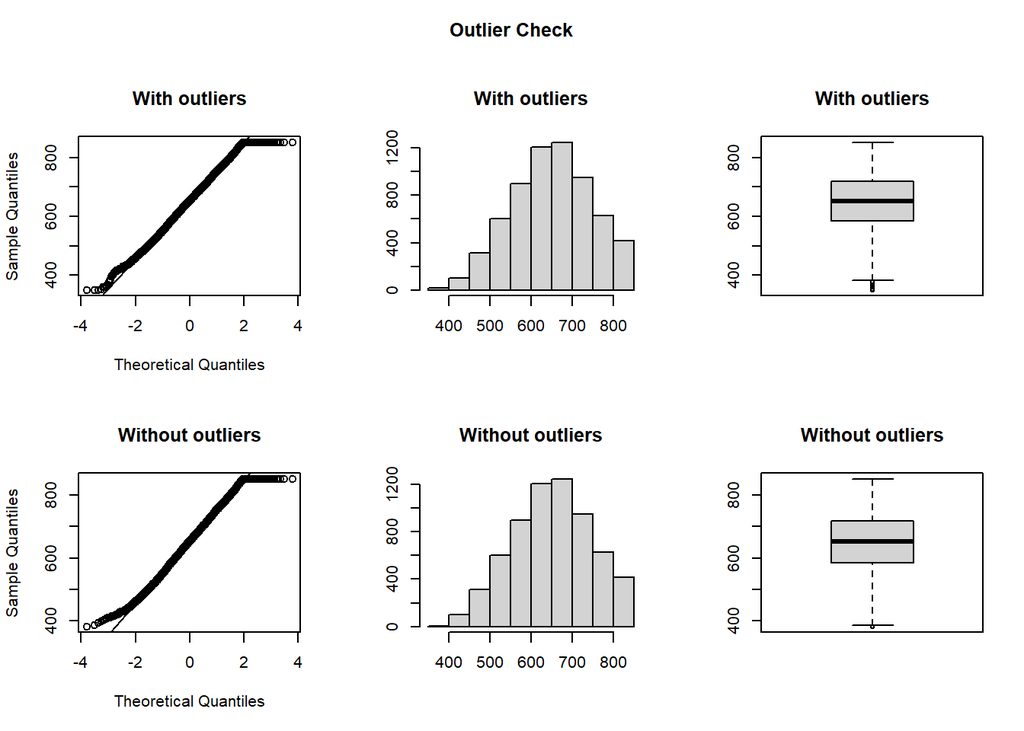

```
## Outliers identified: 10
## Proportion (%) of outliers: 0.2
## Mean of the outliers: 359
## Mean without removing outliers: 651
## Mean if we remove outliers: 652
## Outliers successfully removed
```

```r
# Remove Outliers
churn_data_clean <- outlierKD2(churn_data_clean, CreditScore, rm = TRUE, boxplt = TRUE, histogram = TRUE, qqplt = T)
```

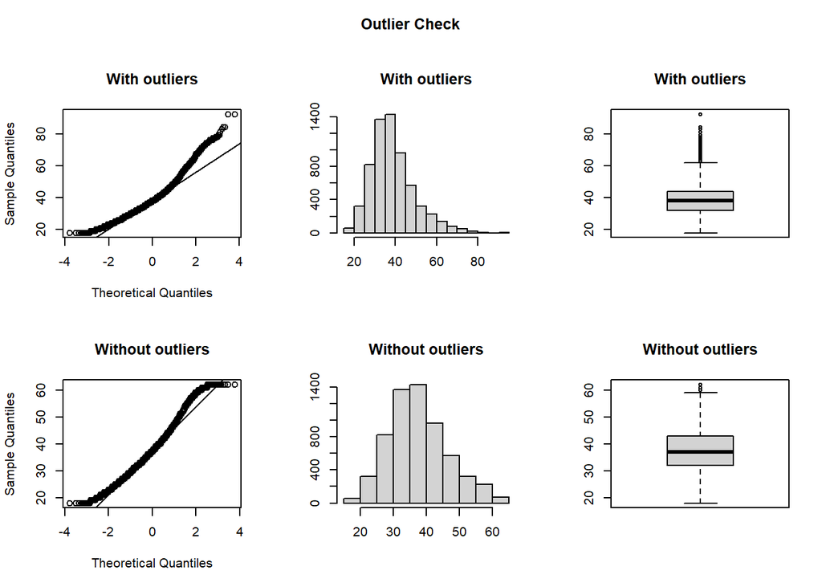

```
## Outliers identified: 225
## Proportion (%) of outliers: 3.7
## Mean of the outliers: 69
## Mean without removing outliers: 39.2
## Mean if we remove outliers: 38.1
## Outliers successfully removed
```

```r
churn_data_clean <- outlierKD2(churn_data_clean, Age, rm = TRUE, boxplt = TRUE, histogram = TRUE, qqplt = T)
```

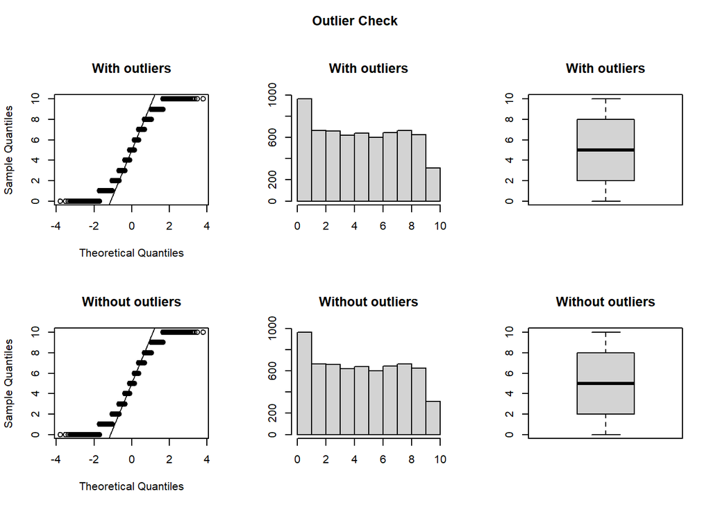

```
## Outliers identified: 0
## Proportion (%) of outliers: 0
## Mean of the outliers: NaN
## Mean without removing outliers: 4.98
## Mean if we remove outliers: 4.98
## Outliers successfully removed
```

```r
churn_data_clean <- outlierKD2(churn_data_clean, Tenure, rm = TRUE, boxplt = TRUE, histogram = TRUE, qqplt = T)
```

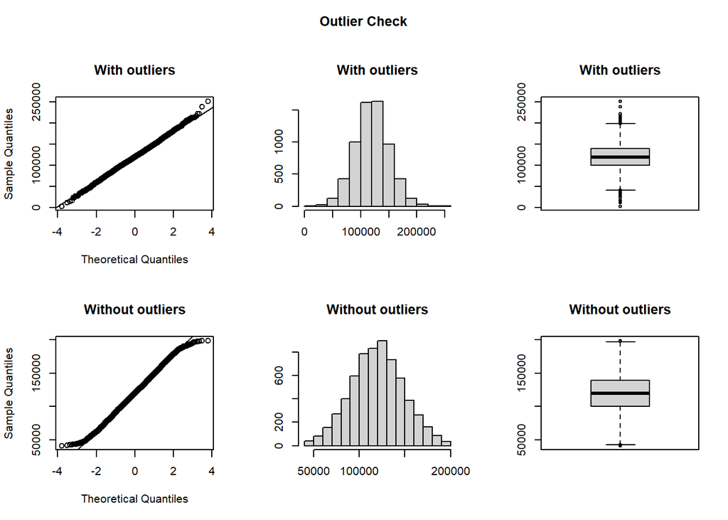

```
## Outliers identified: 73
## Proportion (%) of outliers: 1.2
## Mean of the outliers: 122132
## Mean without removing outliers: 119827
## Mean if we remove outliers: 119801
## Outliers successfully removed
```

```r
churn_data_clean <- outlierKD2(churn_data_clean, Balance, rm = TRUE, boxplt = TRUE, histogram = TRUE, qqplt = T)
```

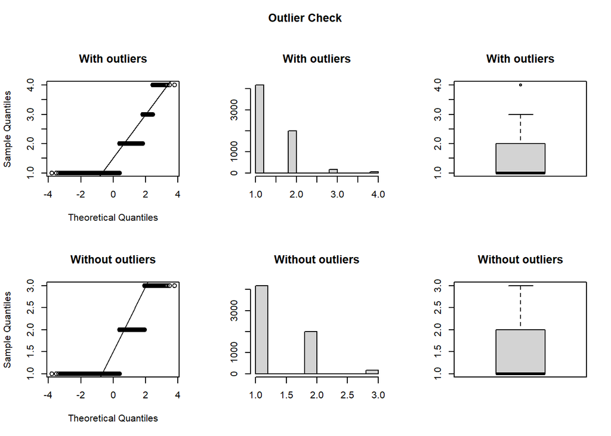

```
## Outliers identified: 46
## Proportion (%) of outliers: 0.7
## Mean of the outliers: 4
## Mean without removing outliers: 1.39
## Mean if we remove outliers: 1.37
## Outliers successfully removed
```

```r
churn_data_clean <- outlierKD2(churn_data_clean, NumOfProducts, rm = TRUE, boxplt = TRUE, histogram = TRUE, qqplt = T)
```

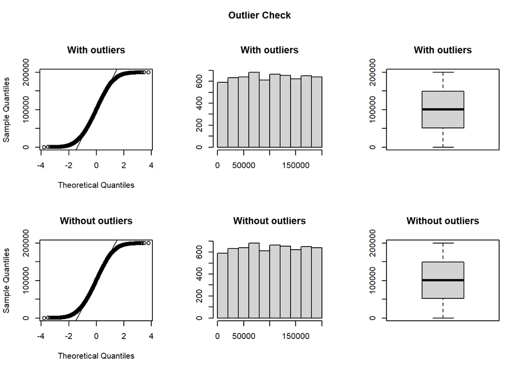

```
## Outliers identified: 0
## Proportion (%) of outliers: 0
## Mean of the outliers: NaN
## Mean without removing outliers: 100717
## Mean if we remove outliers: 100717
## Outliers successfully removed
```

```r
churn_data_clean <- outlierKD2(churn_data_clean, EstimatedSalary, rm = TRUE, boxplt = TRUE, histogram = TRUE, qqplt = T)
```

```r
churn_data_clean <- na.omit(churn_data_clean)
```

We remove any missing values that are in the data set using the na.omit() function.

## Chapter 4: Data Exploration and EDA

### 4.1 Data Exploration

### Credit Score Distribution

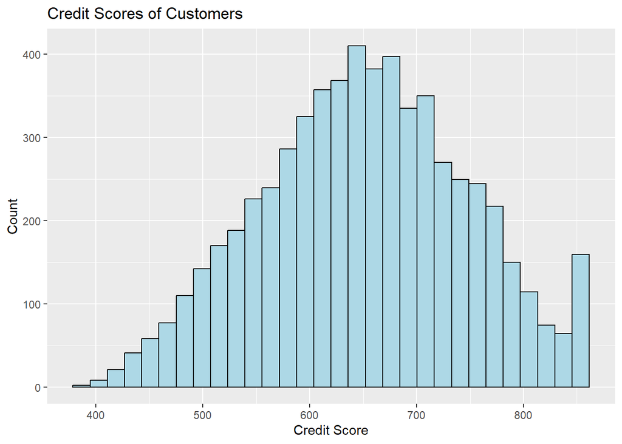

```r
ggplot(churn_data_clean, aes(x = CreditScore)) +
  geom_histogram(colour = "black", fill = "lightblue") +
  labs(title = "Credit Scores of Customers", x = "Credit Score", y = "Count")
```

The average credit score of the customer is 652 most of the customers having credit score fall between 600 to 700 and standard deviation is 96.3. The above histogram shows the range of credit scores.

### Age Distribution

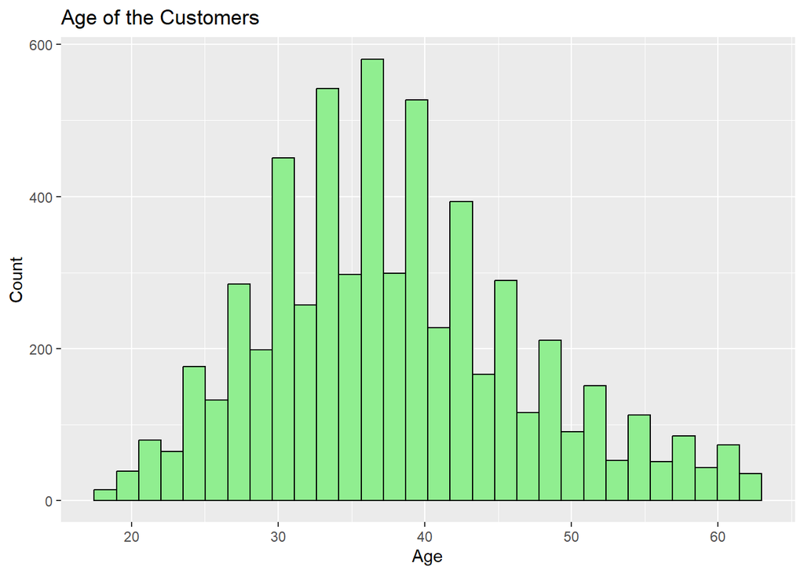

```r
ggplot(churn_data_clean, aes(x = Age)) +
  geom_histogram(color = "black", fill = "lightgreen") +
  labs(title = "Age of the Customers", x = "Age", y = "Count")
```

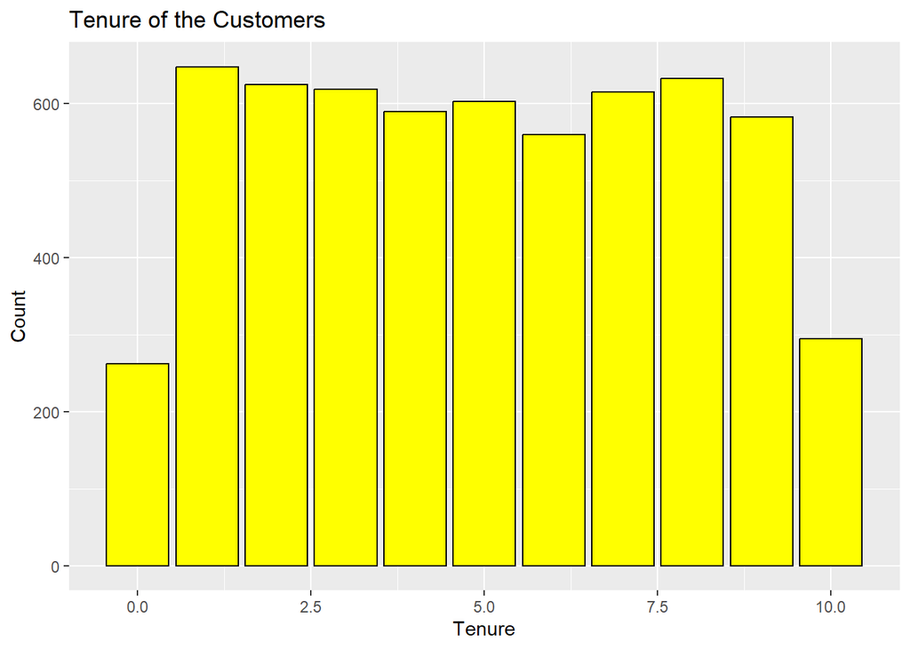

```r
ggplot(churn_data_clean, aes(x = Tenure)) +
  geom_bar(color = "black", fill = "yellow") +
  labs(title = "Tenure of the Customers", x = "Tenure", y = "Count")
```

```r
sd(churn_data_clean$Tenure)
```

```
## [1] 2.91
```

The Bar graph shows the tenure period of a customer in a company.Here we can see that they are equally distributed and they are ranging from 0 to 10 years.From the graph we can see that most of the customers have stayed for more than one year.

### Estimated salaries of the customers

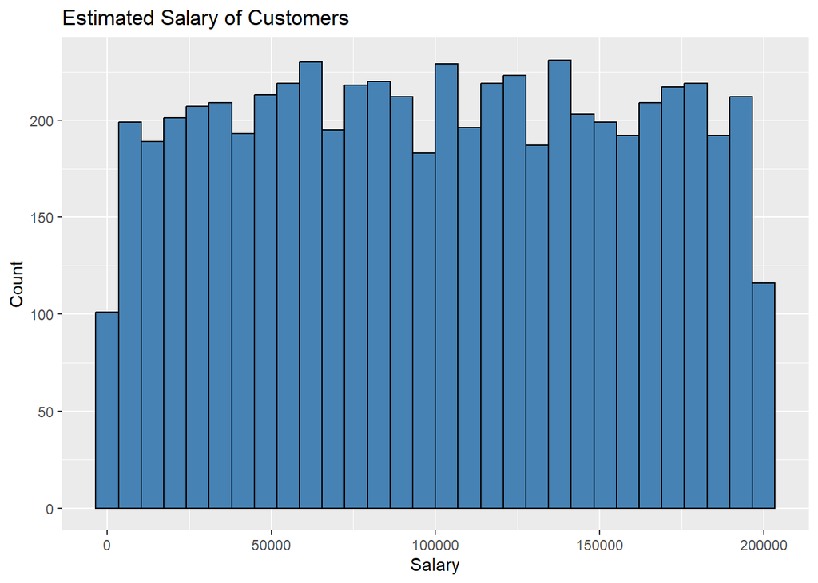

```r
ggplot(churn_data_clean, aes(x = EstimatedSalary)) +
  geom_histogram(color = "black", fill = "steelblue") +
  labs(title = "Estimated Salary of Customers", x = "Salary", y = "Count")
```

The Histogram shows the distribution of estimated salary of customers in the histogram.It is varying from 18 to 200,000 with the mean salary around 100,000.

### Balance Distribution

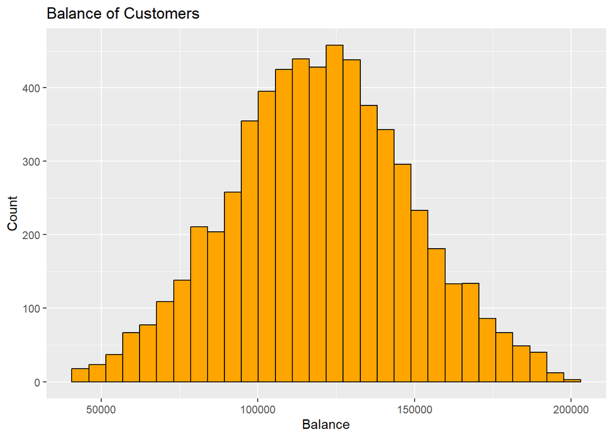

```r
ggplot(churn_data_clean, aes(x = Balance)) +
  geom_histogram(color = "black", fill = "orange") +
  labs(title = "Balance of Customers", x = "Balance", y = "Count")
```

### Number of Products Owned

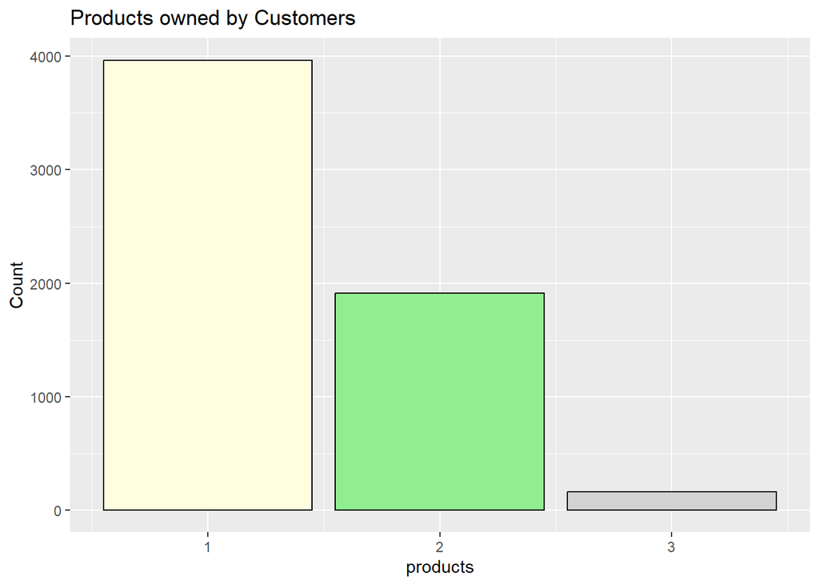

```r
ggplot(churn_data_clean, aes(x = NumOfProducts)) +
  geom_bar(color = "black", fill = c("lightyellow", "lightgreen", "lightgrey")) +
  labs(title = "Products owned by Customers", x = "products", y = "Count")
```

In the bar graph we show the number of products owned by customer.As we can see from the graph most of the customers own 1 or 2 products.

### Number of customers in different countries

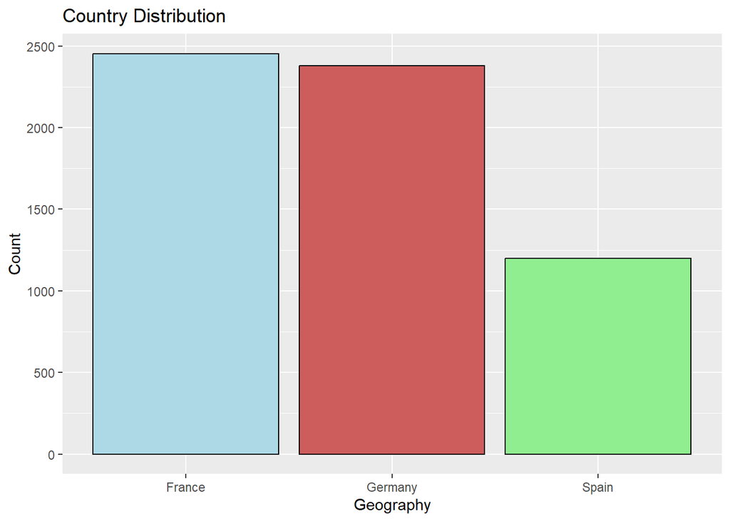

```r
ggplot(churn_data_clean, aes(x = Geography)) +
  geom_bar(color = "black", fill = c("lightblue", "indianred", "lightgreen")) +
  labs(title = "Country Distribution", x = "Geography", y = "Count")
```

In the Distribution we can see that majority of the customers are from France and Germany.

### Gender Distribution

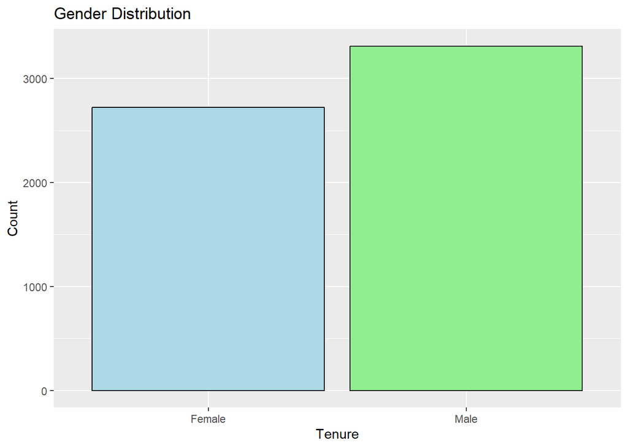

```r
ggplot(churn_data_clean, aes(x = Gender)) +
  geom_bar(color = "black", fill = c("lightblue", "lightgreen")) +
  labs(title = "Gender Distribution", x = "Tenure", y = "Count")
```

From the graph, we can see that there are more male customers than female customers in the dataset.

### Number of credit card holders

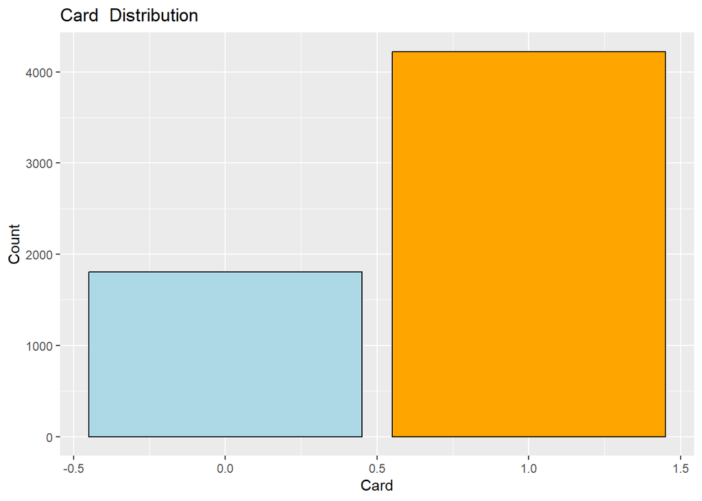

```r
ggplot(churn_data_clean, aes(x = HasCrCard)) +
  geom_bar(color = "black", fill = c("lightblue", "orange")) +
  labs(title = "Card  Distribution", x = "Card", y = "Count")
```

From the bar graph we can see that most of the customers have a credit card from the distribution graph.

### Active Status Distribution

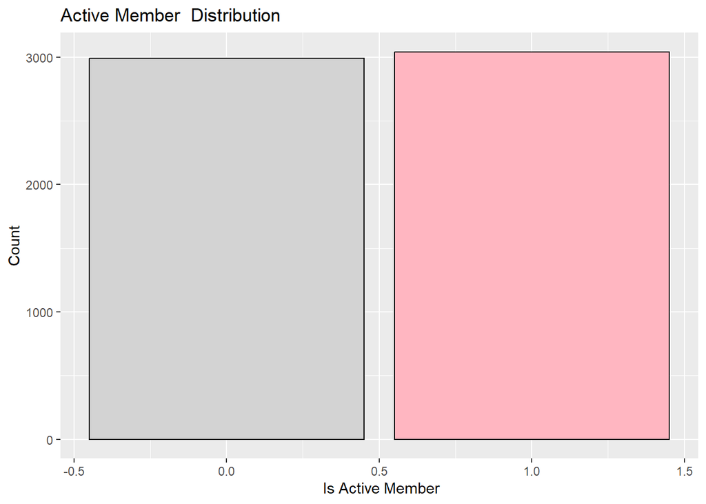

```r
ggplot(churn_data_clean, aes(x = IsActiveMember)) +
  geom_bar(color = "black", fill = c("lightgrey", "lightpink")) +
  labs(title = "Active Member  Distribution", x = " Is Active Member", y = "Count")
```

The distribution of active members and non active members in the dataset is similar but we can see that there are a few more active customers than inactive.

### Churn Distribution

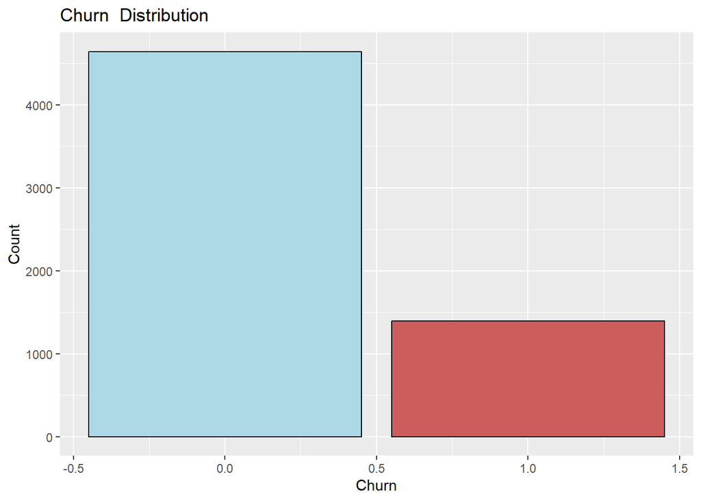

```r
ggplot(churn_data_clean, aes(x = Exited)) +
  geom_bar(color = "black", fill = c("lightblue", "indianred")) +
  labs(title = "Churn  Distribution", x = "Churn", y = "Count")
```

From the graph, we can see that the majority of customers in the dataset have not churned.

### Churn Rate by Geography

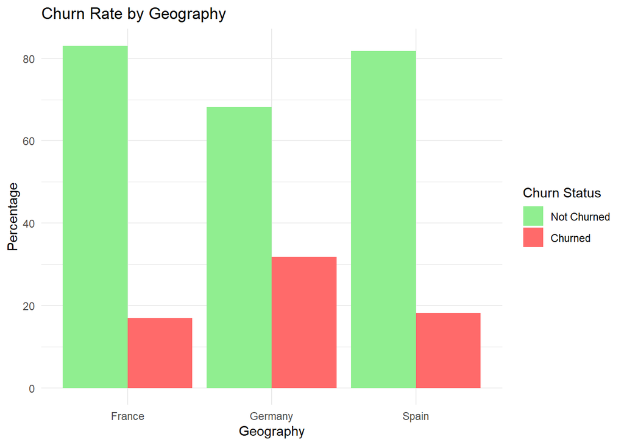

```r
# Plot bar chart for churn rate by geography
churn_geo <- churn_data_clean %>%
  group_by(Geography, Exited) %>%
  summarise(count = n()) %>%
  mutate(percentage = count * 100 / sum(count))

ggplot(churn_geo, aes(x = Geography, y = percentage, fill = factor(Exited))) +
  geom_bar(stat = "identity", position = "dodge") +
  scale_fill_manual(values = c("0" = "lightgreen", "1" = "indianred1"), labels = c("0" = "Not Churned", "1" = "Churned")) +
  labs(x = "Geography", y = "Percentage", fill = "Churn Status") +
  theme_minimal() +
  ggtitle("Churn Rate by Geography")
```

```r
options(dplyr.summarise.inform = FALSE)
```

- The churn rate is highest in **Germany** and lowest in **France**.
- Customers from **Spain** have an intermediate churn rate.
- Further exploration may be needed to identify factors that drive these regional differences (e.g., economic conditions, regional bank policies).

### Churn Rate by Gender

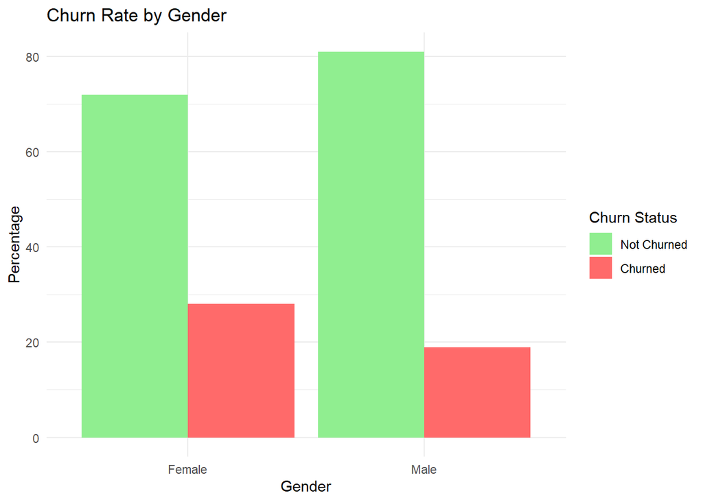

```r
# Plot bar chart for churn rate by gender
churn_gender <- churn_data_clean %>%
  group_by(Gender, Exited) %>%
  summarise(count = n()) %>%
  mutate(percentage = count * 100 / sum(count))

ggplot(churn_gender, aes(x = Gender, y = percentage, fill = factor(Exited))) +
  geom_bar(stat = "identity", position = "dodge") +
  scale_fill_manual(values = c("0" = "lightgreen", "1" = "indianred1"), labels = c("0" = "Not Churned", "1" = "Churned")) +
  labs(x = "Gender", y = "Percentage", fill = "Churn Status") +
  theme_minimal() +
  ggtitle("Churn Rate by Gender")
```

- The churn rate is higher among **Female** customers compared to **Male** customers.
- This implies that female customers may be more sensitive to certain factors that contribute to churn.

### Age Distribution by Churn Status

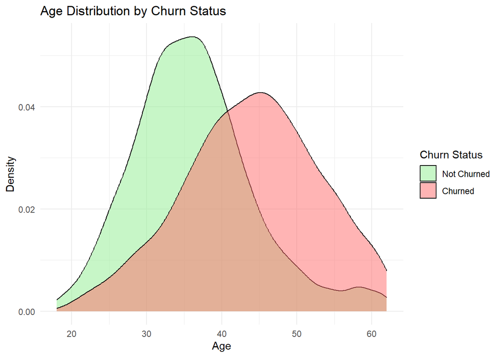

```r
# Plot density plot for age distribution by churn status
ggplot(churn_data_clean, aes(x = Age, fill = factor(Exited))) +
  geom_density(alpha = 0.5) +
  labs(x = "Age", y = "Density", fill = "Churn Status") +
  theme_minimal() +
  ggtitle("Age Distribution by Churn Status") +
  scale_fill_manual(values = c("0" = "lightgreen", "1" = "indianred1"), labels = c("0" = "Not Churned", "1" = "Churned"))
```

- The age distribution of customers who churned is more spread out compared to the age distribution of those who did not churn.
- The peak churn rate for churned customers occurs within the age range of **44 to 46 years**.
- The age distribution of customers who did not churn has a taller peak, indicating a higher concentration of customers in a specific age range who are less likely to leave the bank.

### Credit Score Distribution by Churn Status

The box plot for the given data displays the distribution of credit scores by churn status. It has two box plots, one for customers who have not churned (`Exited = 0`) and one for customers who have churned (`Exited = 1`).

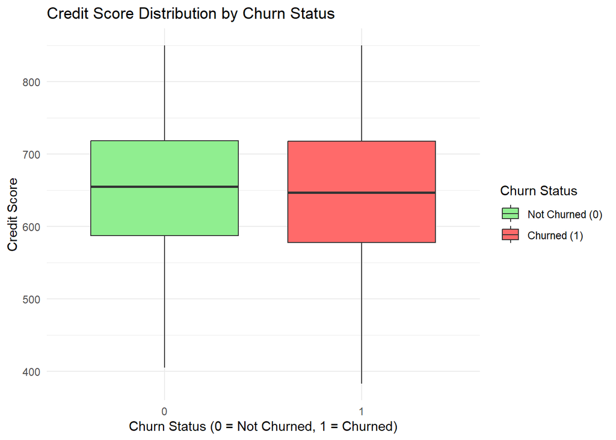

```r
ggplot(churn_data_clean, aes(x = factor(Exited), y = CreditScore, fill = factor(Exited))) +
  geom_boxplot() +
  labs(x = "Churn Status (0 = Not Churned, 1 = Churned)", y = "Credit Score", fill = "Churn Status") +
  theme_minimal() +
  ggtitle("Credit Score Distribution by Churn Status") +
  scale_fill_manual(values = c("0" = "lightgreen", "1" = "indianred1"), labels = c("0" = "Not Churned (0)", "1" = "Churned (1)"))
```

Based on the box plot, we can make the following observations:

- The median credit score for both groups (churned and not churned) is quite similar(around 650), indicating that there might not be a significant difference in *the central tendency* of credit scores between the two groups.
- The overall range of credit scores and *the interquartile ranges* for both groups are also quite similar, suggesting that *the spread* of credit scores is not considerably different between the churned and not churned groups.

### Credit Score Distribution by Churn Status

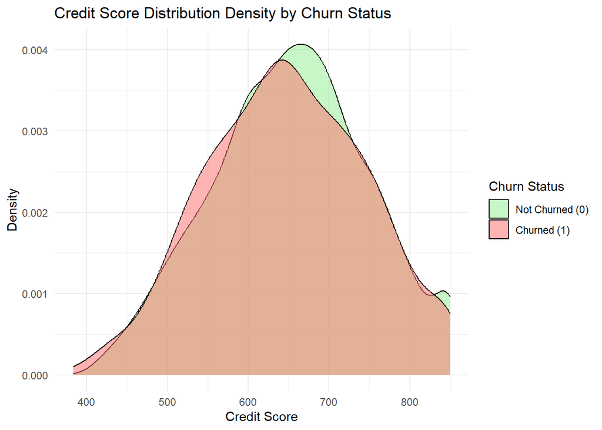

```r
ggplot(churn_data_clean, aes(x = CreditScore, fill = factor(Exited))) +
  geom_density(alpha = 0.5) +
  labs(x = "Credit Score", y = "Density", fill = "Churn Status") +
  theme_minimal() +
  ggtitle("Credit Score Distribution Density by Churn Status") +
  scale_fill_manual(values = c("0" = "lightgreen", "1" = "indianred1"), labels = c("0" = "Not Churned (0)", "1" = "Churned (1)"))
```

The density plot for the given data displays the distribution of credit scores by churn status using smooth, continuous lines. The plot has two density curves:

- **Customers who have not churned** (Exited = 0): shown in light green
- **Customers who have churned** (Exited = 1): shown in indianred1

### 4.2 Hypothesis Tests

### T-test on Credit Score and Churn

We will perform an independent two-sample t-test to determine if there is a significant difference in the mean credit scores between customers who churned and those who did not churn.

H0: The mean credit scores of churned customers and non-churned customers are equal. H1: The mean credit scores of churned customers and non-churned customers are not equal.

```r
churned <- churn_data_clean %>%
  filter(Exited == 1) %>%
  pull(CreditScore)
non_churned <- churn_data_clean %>%
  filter(Exited == 0) %>%
  pull(CreditScore)

ttest_result <- t.test(churned, non_churned)

# Display t-test results
ttest_result
```

```
##
##  Welch Two Sample t-test
##
## data:  churned and non_churned
## t = -2, df = 2246, p-value = 0.05
## alternative hypothesis: true difference in means is not equal to 0
## 95 percent confidence interval:
##  -11.575   0.113
## sample estimates:
## mean of x mean of y
##       647       653
```

The t-test aimed to determine if there was a significant difference in the mean credit scores between customers who churned and those who did not churn. The null hypothesis (H0) stated that the mean credit scores of churned customers and non-churned customers were equal, while the alternative hypothesis (H1) stated that they were not equal.

The t-test results showed a p-value of 0.055, which is greater than the 0.05 significance level. Therefore, we failed to reject the null hypothesis. This suggests that there is no significant difference in the mean credit scores between churned and non-churned customers.

### One-way ANOVA on Categorical Credit Score

Next, we created categories for the CreditScore variable by dividing it into bins and performed a one-way ANOVA test. The test aimed to determine if there was a significant difference in the mean churn rate among the different categories of credit scores. The null hypothesis (H0) stated that the mean churn rates among the different categories of credit scores were equal, while the alternative hypothesis (H1) stated that at least one of the mean churn rates was not equal.

```r
# Create bins for CreditScore
churn_data_clean <- churn_data_clean %>%
  mutate(CreditScoreCat = cut(CreditScore, breaks = seq(350, 850, by = 125), include.lowest = TRUE, labels = c("Low", "Medium", "High", "Very High")))

# Display the first few rows with the new categorical variable
head(churn_data_clean)
```

```
##   RowNumber CustomerId  Surname CreditScore Geography Gender Age Tenure Balance
## 1         2   15647311     Hill         608     Spain Female  41      1   83808
## 2         3   15619304     Onio         502    France Female  42      8  159661
## 3         5   15737888 Mitchell         850     Spain Female  43      2  125511
## 4         6   15574012      Chu         645     Spain   Male  44      8  113756
## 6         9   15792365       He         501    France   Male  44      4  142051
## 7        10   15592389       H?         684    France   Male  27      2  134604
##   NumOfProducts HasCrCard IsActiveMember EstimatedSalary Exited CreditScoreCat
## 1             1         0              1          112543      0           High
## 2             3         1              0          113932      1         Medium
## 3             1         1              1           79084      0      Very High
## 4             2         1              0          149757      1           High
## 6             2         0              1           74941      0         Medium
## 7             1         1              1           71726      0           High
```

```r
# Create a new data frame with just churn and categorical credit scores
churn_credit_score <- churn_data_clean %>%
  select(Exited, CreditScoreCat)

# Group by categorical credit score and calculate the mean churn rate
churn_rate_by_credit_score <- churn_credit_score %>%
  group_by(CreditScoreCat) %>%
  summarise(MeanChurnRate = mean(Exited))

# Perform the one-way ANOVA test
anova_result_churn <- aov(Exited ~ CreditScoreCat, data = churn_credit_score)

# Display ANOVA results
summary(anova_result_churn)
```

```
##                  Df Sum Sq Mean Sq F value Pr(>F)
## CreditScoreCat    3      1   0.330    1.86   0.13
## Residuals      6029   1070   0.177
```

The one-way ANOVA test results showed a p-value of 0.134, which is greater than the 0.05 significance level. Thus, we failed to reject the null hypothesis. This indicates that there is no significant difference in the mean churn rates among the different categories of credit scores.

## Chapter 5: Conclusion

Our EDA provided insights into the impact of geography, gender, and age on customer churn:

- Churn rate is higher in Germany and among female customers.
- Churned customers tend to be in the 44-46 age range.

Our S.M.A.R.T. question aimed to explore the relationship between credit scores and customer churn for customers with a balance greater than zero.

We conducted the following statistical tests to analyze this relationship:

- A t-test comparing mean credit scores between churned and non-churned customers showed a p-value of 0.0546, suggesting a weak statistical significance.
- Categorized credit scores and performed a one-way ANOVA test. Our findings indicate no significant difference in mean churn rates among the credit score categories.

In conclusion, as the credit score shows a weak correlation with customer churn, it may not be a robust predictor on its own. Additional factors should be considered to better understand and address customer churn.

## Chapter 6: References

Kaemingk, D. (2018, August 29). Reducing customer churn for banks and financial institutions. Qualtrics. Retrieved November 2, 2022

Guliyev, H., & Yerdelen Tatoğlu, F. (2021). Customer churn analysis in banking sector: Evidence from explainable machine learning models. Journal of Applied Microeconometrics, 1(2), 85–99.

Alsheref, F. K., Hussein, S. A., Abdelrahman, A. M., Abou el Kassem, E., & Mostafa, A. (2020) Customer Churn Prediction Model and Identifying Features to Increase Retention. (n.d.). Retrieved from https://thesai.org/Downloads/Volume11No5/Paper_67-Customer_Churn_Prediction_Model.pdf